# Preface

Author

Michael Betancourt

Published

February 2023

Common experience tells us that unsupported objects fall towards the ground under the influence of Earth’s gravity. To understand this phenomenon more *quantitatively* we need to compare observations of falling objects to mathematical models, each capturing a distinct story of how objects fall. In particular we might carefully observe the trajectory that a ball traces out after it is released and then compare those observations to different mathematical models for that motion given the ball’s initial height and velocity and the local acceleration due to gravity.

If the measurements were infinitely precise (Figure 1 (a)) then we would be able to exclude any model that doesn’t *exactly* reproduce the observed trajectory (Figure 1 (b)).

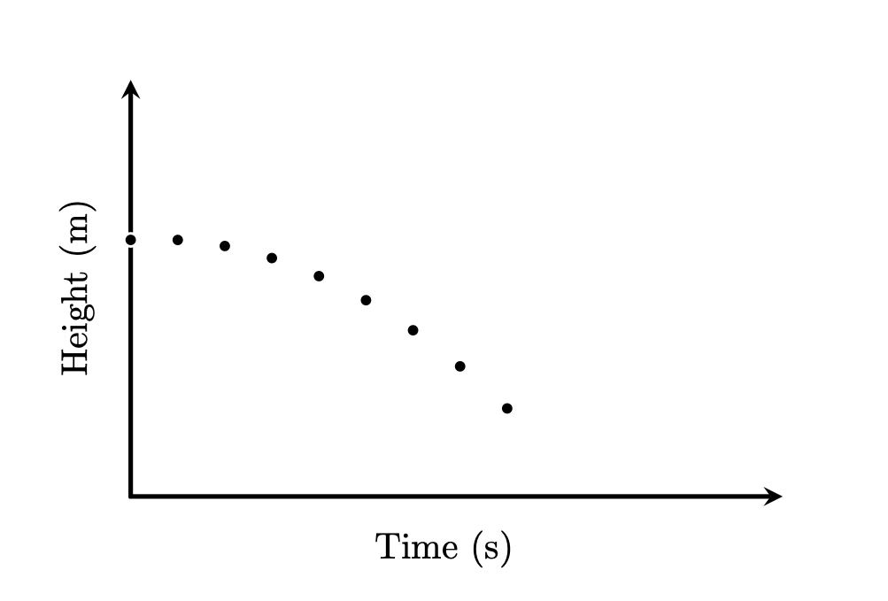

(a)

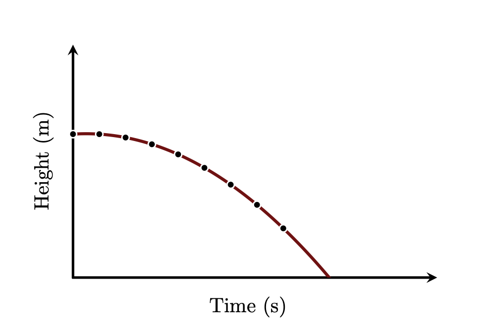

(b)

Figure 1: In an ideal world (a) infinitely precise observations of a falling ball (b) would exclude all mathematical models of gravity except for those that exactly reproduce the observations.

Unfortunately even the most skilled scientist cannot achieve infinitely precise measurements. Practical measurements of a falling object are limited not only by chaotic atmospheric forces imparted on the ball as it falls but also finite spatial resolution. Even if we knew the true model we still would not be able to exactly predict the outcome of each measurement (Figure 2).

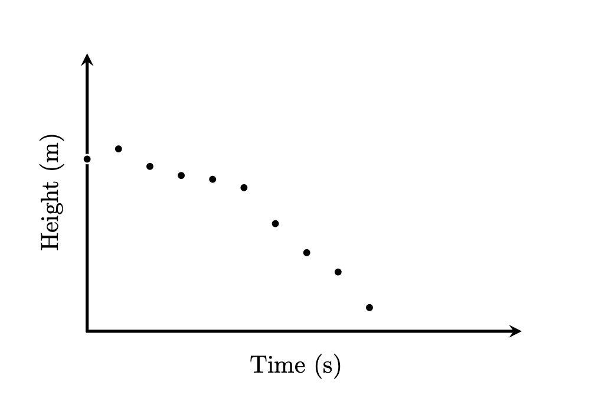

Figure 2: Realistic measurements are unpredictable, at best scattering around the true model.

Without precise predictability we cannot exclude most models outright; just about every model will perfectly reproduce a given observation with a sufficiently convenient fluctuation in the measurement. Even if we can restrict consideration to *typical* fluctuations many different gravitational models will be consistent with the observed data (Figure 3).

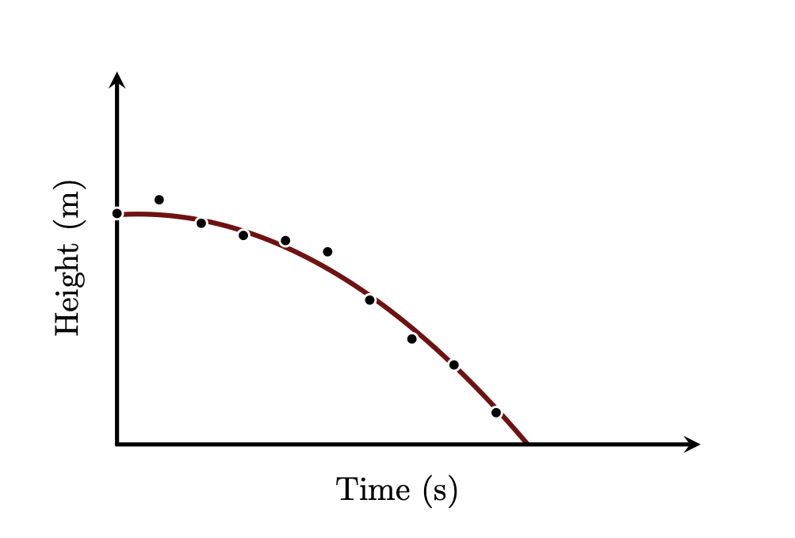

(a)

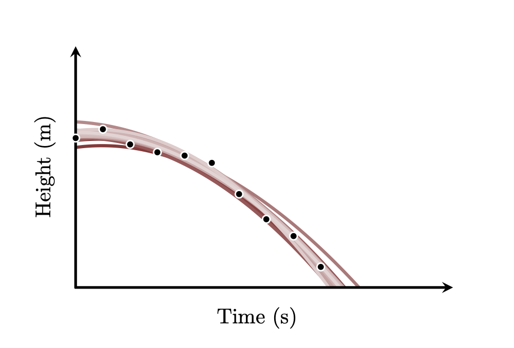

(b)

Figure 3: The lack of predictability in practical measurements complicates learning from data. (a) Every model that is consistent with a noisy observation is accompanied by (b) many other models that are similarly consistent.

In other words any inferences we can draw from a realistic observation will be fundamentally *uncertain*. If we want to extract robust insights from data we have to face this uncertainty.

Consider, for example, learning about the environment around us through experiment and observation, either for pure curiosity or to inform particular decisions about how to interact with that environment. The **scientific method** organizes this learning process into a systematic procedure (Figure 4).

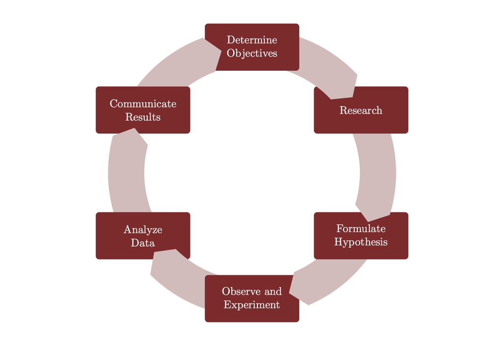

Figure 4: The scientific method reduces the process of learning from experiment and observation into a sequence of basic steps, including one where we have to draw inferences from observed data.

While the basic steps of this procedure might appear straightforward, the complexity of scientific inquiry is hidden in the details of their implementation. In particular when trying to implement the “Analyze Data” step we have to confront the fundamental limitations in measurements and determine how to quantify our inferential uncertainty. Formally quantifying inferential uncertainty is exactly the goal of **statistical inference**.

To realize the “Analyze Data” step, and hence the scientific method as a whole, we have to encode our knowledge into mathematical models, identify how consistent those models are with a given observation, and then verify that the consistent models adequately reproduce the structure of that observation (Figure 5). As George Box noted we cannot do rigorous science without rigorous statistical modeling and inference (Box 1976).

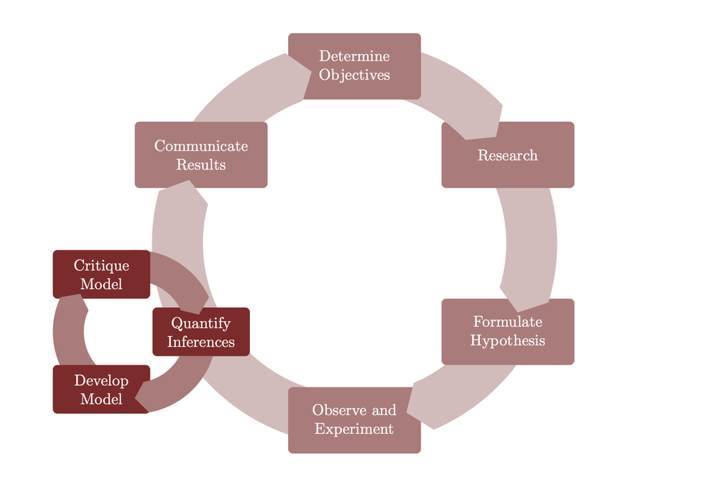

Figure 5: Each step in the scientific method encapsulates many critical implementation details. For example in order to “Analyze Data” we need to be able to develop candidate mathematical models, each representing one way that observations could be generated, and then quantifying how consistent each of those models are with an actual observation.

In this book we will learn how to use **Bayesian inference** to analyze data and, ultimately, implement the scientific method for both scientific and industrial applications. Bayesian inference uses **probability theory** to not only develop **probabilistic models** of measurements but also to quantify how consistent those models are with our domain expertise and observed data (Figure 6)

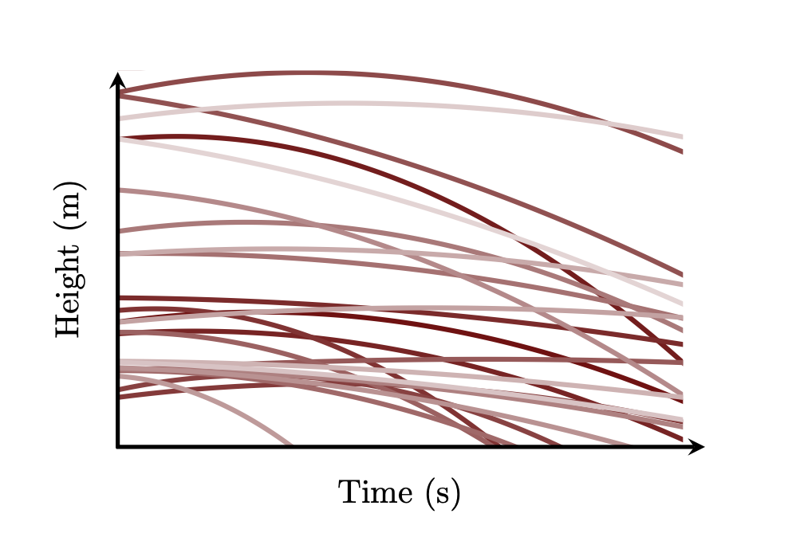

(a)

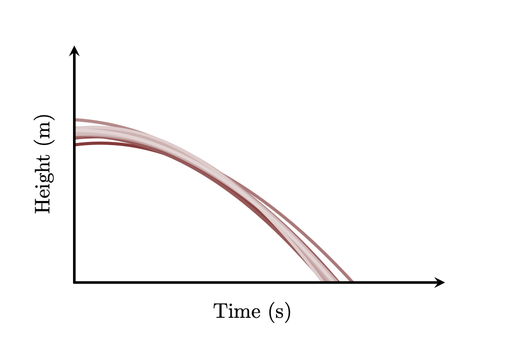

(b)

Figure 6: Bayesian inference uses probability theory to quantify which models (a) how a priori consistent models are with any available domain expertise and then (b) how a posteriori consistent they are with both the available domain expertise and any observed data.

Although Bayesian inference is conceptually elegant its practical implementation is far from trivial. In order to implement a successful Bayesian analysis we need to be proficient with not only building models but also critiquing their adequacy in a particular application and accurately quantify their consistency with observed data. This books considers not only the conceptual foundations of Bayesian inference but also these implementation challenges so that by its conclusion you will be prepared to build the *bespoke* analysis unique to your particular application.

# 1 The Pedagogical Approach Of This Book

To execute such an ambitious goal as painlessly as possible we need a careful *pedagogical* strategy. What is the best way to learn how to robustly implement Bayesian analyses?

In this section I’ll discuss what I think is the best way to learn Bayesian inference and hence why this book is structured so differently from many other introductions to Bayesian analysis.

## 1.1 Abstractions

Most subjects, including Bayesian inference are conceptually dense. While they might superficially appear simple the more closely we examine them the more detail we need to confront in order to form a coherent theory. In order to make a subject approachable for students we have to rely on pedagogical **abstractions** that hide the overwhelming depth behind only a selection of concepts that are easier to digest.

A good abstraction focuses on simple concepts that are mostly consistent with each other. This consistency keeps the abstraction largely self-contained, obscures the hidden depth below. Scrutinizing the inconsistencies that do manifest in a given abstraction, however, will eventually lead us beyond the boundaries of that abstraction and into the domain of a new, deeper abstraction. When developing practical methodologies we need to find a sufficiently rich abstraction that captures all of the necessary concepts without too much unnecessary detail.

Consider, for example, the real numbers. At a high-level we can conceptualize the real numbers as a *continuum* with infinite detail no matter how closely we zoom in. This is a completely reasonable abstraction for most applications involving not only basic arithmetic but also more complicated operations like differentiation and integration. When we want to engage in more technical results, however, we will need to go beyond this simple abstraction in order to develop a consistent theory free of pathological behavior.

Abstractions also play a role in how real numbers are implemented in practice. At a high-level we can assume that computers are able to exactly represent real numbers and exactly implement their arithmetic operations. In many applications this abstraction is entirely valid. When working on applications that require precise or complicated calculations, however, we start to see cracks in this conceptual picture.

Eventually we have to confront the reality of the *finite precision arithmetic* implemented on computers and how it deviates from exact arithmetic. Going slightly deeper we might consider the limited dynamic range of *floating point* numbers that can result in underflow and overflow for particularly small and large results. Digging even further we might tackle how underflow and overflow in intermediate calculations can lead to catastrophic errors even if the final result is not itself extremely small or large.

## 1.2 Sequences of Abstractions

In most applications an abstraction that is sufficiently detailed is too overwhelming to approach all at once. Instead we have to progress towards it carefully through a sequence of intermediate abstractions. This leaves us to consider the progressions that best guide students towards that terminal abstraction.

### 1.2.1 Non-Overlapping Progressions

One approach, for example, utilizes a progression of *non-overlapping* abstractions (Figure 7). This allows the intermediate abstractions to incorporate compelling intuitions and examples even if they don’t generalize to the final abstraction. Moreover each abstraction can be compartmentalized into a relatively self-contained course, and different students with different goals can follow the progression to different terminal abstractions. For these reasons this approach is particularly common in academia.

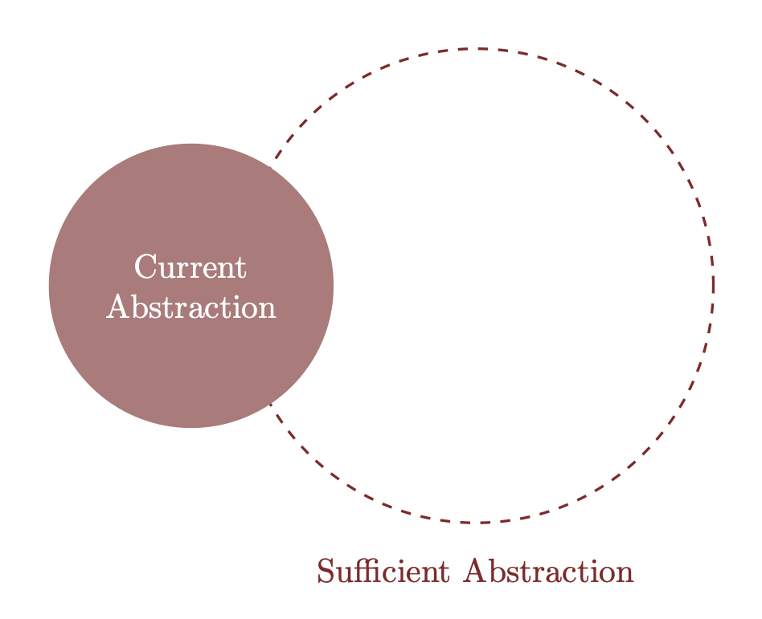

(a)

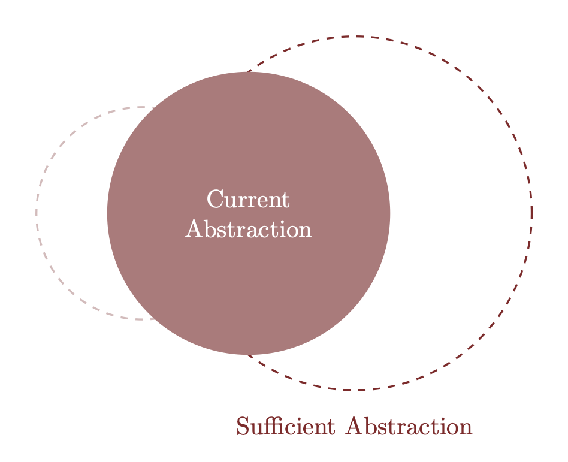

(b)

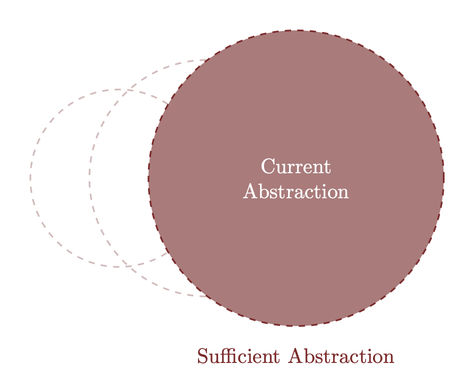

(c)

Figure 7: Non-overlapping progressions build up to a final, sufficient abstraction through inconsistent intermediate abstractions. At each iteration only some of the concepts are carried forward to the new, more detailed abstraction.

Non-overlapping progressions can be problematic, however, when the sequence of intermediate abstractions terminates prematurely. The insights of the last intermediate abstraction encountered might be useful in some circumstances, but without the context of the remaining abstractions a student will likely have difficulty identifying exactly what those necessary circumstances, let alone validating when they hold in a given application. In other words the understanding offered by only an intermediate abstraction can be *fragile* when the assumptions holding that abstraction together cannot be taken for granted.

Another problem with this approach is that the updating from one abstraction to the next can be burdensome on students. Because the abstractions don’t overlap a student doesn’t just expand their understanding with new concepts at each iteration; instead they also have to *unlearn* the concepts that don’t generalize from the previous abstraction (Figure 8). This repeated cycle of learning and unlearning can be frustrating and even discourage students from moving past an intermediate, and potentially fragile, abstraction.

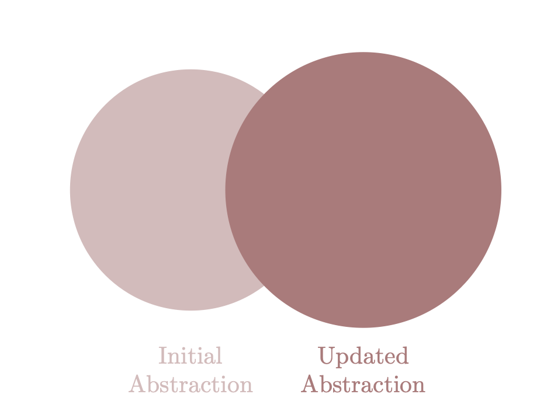

(a)

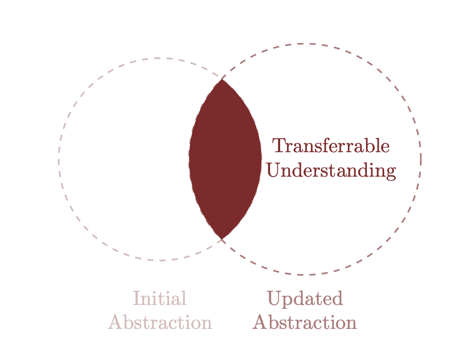

(b)

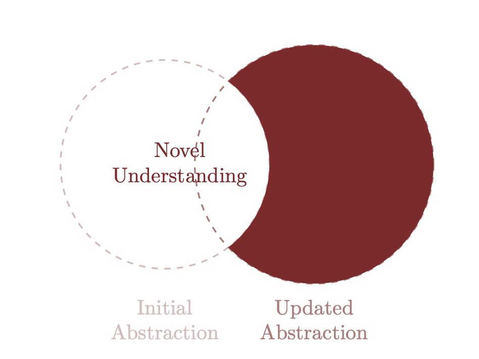

(c)

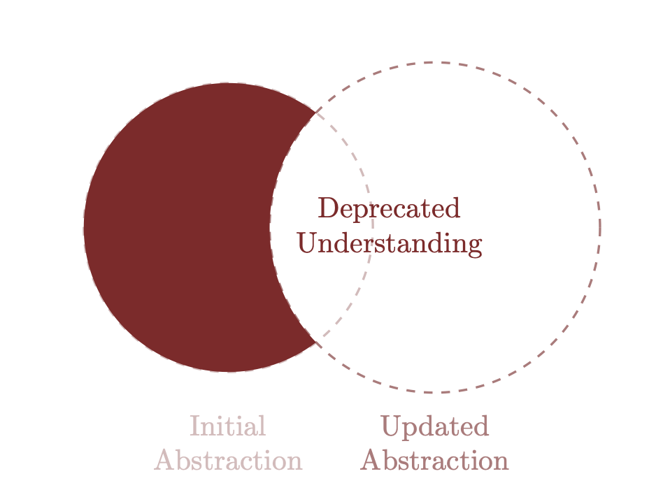

(d)

Figure 8: The (a) inconsistent abstractions in a non-overlapping progression can frustrate learning. At each iteration (b) only some concepts will generalize and transfer from one abstraction to the next and (c) the newer abstraction will also introduce new concepts that have to be learned. (d) Some concepts in the initial abstraction, however, will not generalize. Students have to actively *unlearn* these concepts in order to fully grasp the newer abstraction.

For example a non-overlapping approach towards teaching arithmetic on computers might start by assuming that computers implement arithmetic exactly. In this case the initial abstraction can demonstrate implementation with simple programs that define real variables and evaluate arithmetic operations with negligible error. Students can then use these initial insights to write new programs that can yield reasonable results in many cases but might exhibit large, often ignored errors in others. A following abstraction might introduce programs that explicitly demonstrate errors before introducing the practical reasons why real numbers and their basic operations can’t be exactly implemented on computers with finite resources. The progression could then continue to abstractions that introduce the basic structure of fixed-point and floating-point arithmetic and their pitfalls before presenting the technical details of fixed-point and floating-point arithmetic implementations on contemporary computers.

### 1.2.2 Overlapping Progressions

Alternatively we can build up to that final, sufficient abstraction with a progression of *overlapping* abstractions (Figure 9). By avoiding concepts that don’t persist to the final abstraction entirely nothing has to be unlearned, and students can instead focus on expanding their understanding to the new concepts introduced at each iteration.

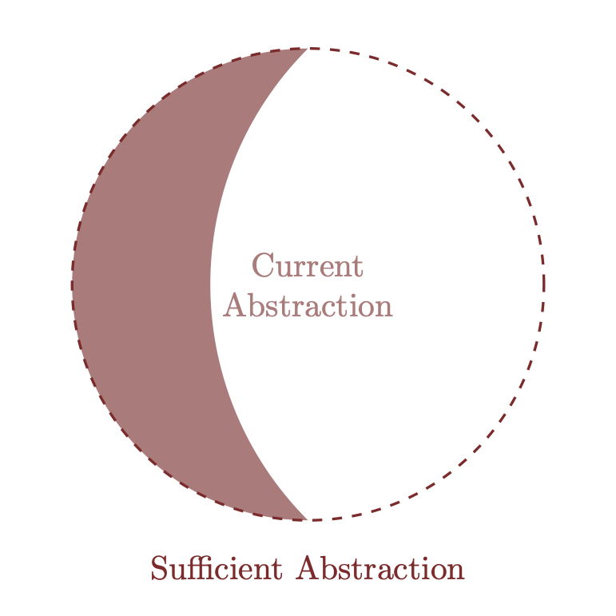

(a)

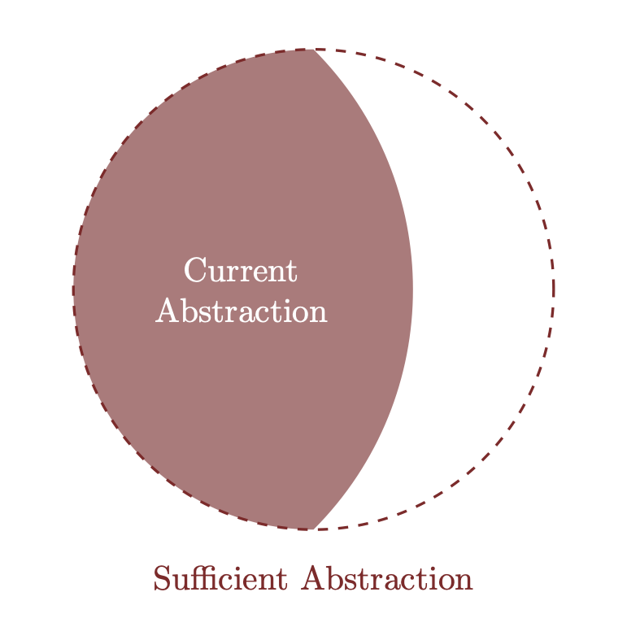

(b)

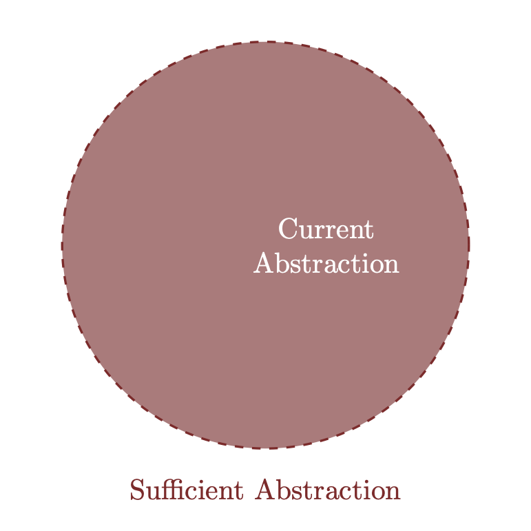

(c)

Figure 9: Overlapping progressions build up to a final, sufficient abstraction through consistent intermediate abstractions. At each iteration all of the concepts are carried forward to the new, more detailed abstraction avoiding any need to unlearn deprecated concepts.

For example an overlapping approach to teaching computer arithmetic might start not with any demonstrative code but rather a discussion of the infinite memory it would take to store an arbitrary real number, the infinite processing power it would take to evaluate arithmetic for arbitrary real numbers. A subsequent abstraction might consider the various ways that we can theoretically approximate real numbers and their operations with only finite memory and finite processing power. Without explicit implementations, and code demonstrating those implementations, there is nothing that students can abuse but also nothing with which students can experiment and build their comprehension. Only in later abstractions where we see how finite-precision arithmetic is implemented will we be able to construct interactive examples.

## 1.3 Why This Book Is So Long

I think that it’s fair to say that most pedagogical resources take a non-overlapping approach to teaching statistics in general, let alone Bayesian inference in particular. In order to reach demonstrative examples as soon as possible these resources typically begin with simple models and little if any critique of the assumptions implied by those models. At the same time the construction of inferences from these models is often delegated to tools whose accuracy is taken for granted. Few resources move beyond these relatively shallow abstractions leaving students unaware at how fragile some of the insights might be.

Many of these resources inspire enthusiasm for Bayesian inference which, and I mean this sincerely, cannot be discounted. Enthusiasm alone, however, may not be enough for students to avoid the consequences of fragile insights. Many students struggle to connect the simple models of shallow abstractions to their own applications. Some identify the problematic consequences of applying simple models when they’re not appropriate but, without a broader context, mistakenly blame their own implementation of those models and not the models themselves.

This book is for those students. I embrace an overlapping progression to deliberately, if slowly, develop the probabilistic tools needed to build *bespoke* models appropriate to a particular application and implement *faithful* Bayesian inference that accurately quantifies uncertainty for those models. Our goal is artisanal models, not something mass produced and sold at big box stores.

Depending on your previous experience with probabilistic modeling and Bayesian inference you may find useful insights by jumping straight into later chapters. That said this book is designed to be read from beginning to end as concepts, terminology, and mathematical notation are all built up progressively from the beginning. Starting from the beginning will also help you confront and unlearn any misconceptions about probability, modeling, and inference that you may have picked up along your journey.

I do not assume any prior knowledge of the theory or practical implementation of probability theory, probabilistic modeling, or Bayesian inference, but I do assume some basic mathematical experience. In particular the book will require a conceptual understanding of calculus, namely the basic theory and implementation of differentiation and integration, as well as working knowledge of linear algebra.

Most introductory calculus textbooks, such as Larson, Hostetler, and Edwards (2005) and Stewart (2015), will cover the relevant concepts. More sophisticated treatments like Apostol (1967) and Apostol (1969) aren’t necessary but can be helpful references when looking into some more subtle technical details. For linear algebra Trefethen and Bau (1997) is particularly thorough about not just the basic of linear algebra but also the common pitfalls of its practical implementation.

Later chapters introduce code demonstrations in `R` and `Python`. If you are comfortable with either language then I encourage you to not just look through the code but also run it yourself. Playing around with these code demonstrations is a powerful way to develop and reinforce your comprehension.

The Carpentries offer a [variety of workshops](https://carpentries.org/workshops-curricula/#swc-all) that introduce both `R` and `Python`. Jenny Bryant’s [Stat545 course material](https://stat545.com) is another great resource for introducing oneself to `R` and Sweigart (2019) is a nice resource for learning `Python`.

# 2 Outline

With all of that said let’s look at the pedagogical progression of this book in a bit more detail. The book it organized into three parts: the first focuses on applied probability theory, the second on the general principles of probabilistic modeling and statistical inference, and the third on particular modeling techniques.

In Part I we will learn the mathematical properties of probability distributions, the operations that we can use to manipulate probability distributions, and some of the most useful methods for approximately implementing those operations in practice. The first few chapters will necessarily be a bit abstract until we can properly set up those implementations but your patience will be rewarded. Overall these chapter will go into much more detail about probability theory than most introductions to Bayesian inference, although that that detail will focus on conceptual understanding and practical insights rather than technical formalities and proofs.

A thorough understanding of applied probability theory sets the stage for Part II where we will use probability distributions to quantify unpredictable measurements in theory, approximately model the processes which give rise to measurements in practice, and quantify our uncertainty about how consistent various approximations are with the outcome of a specific measurement. In particular we will focus on techniques to translate our understanding of a system and measurements that interrogate that system into bespoke probabilistic models capable to gleaming precise insights from data.

With that conceptual foundation established Part III considers particular modeling techniques that can be useful as modular building blocks for developing these bespoke models. Each chapter focuses on not only the assumptions inherent to a given technique and how to validate those assumptions but also on efficient implementations. Many of the chapters will consider popular estimation techniques from the modeling perspective we need to rigorously integrate them into Bayesian analyses.

Although Part III introduces many modeling techniques it is by no means exhaustive. One of the exciting aspects of probabilistic modeling is an eternal opportunity to learn new techniques, expanding our modeling toolkit and the sophistication of bespoke models that we can employ in practice. This book will hopefully prepare you for that never-ending, but never-boring journey.

# 3 Acknowledgements

I thank Ero Carrera for helpful comments.

# License

A repository containing all of the files used to generate this chapter is available on [GitHub](https://github.com/betanalpha/quarto_chapters/tree/main/preface).

The text and figures in this chapter are copyrighted by Michael Betancourt and licensed under the CC BY-NC 4.0 license:

https://creativecommons.org/licenses/by-nc/4.0/

## References

Apostol, Tom M. 1967. *Calculus. Vol. I: One-Variable Calculus, with an Introduction to Linear Algebra*. Second. Blaisdell Publishing Co. [Ginn; Co.], Waltham, Mass.-Toronto, Ont.-London.

———. 1969. *Calculus. Vol. II: Multi-Variable Calculus and Linear Algebra, with Applications to Differential Equations and Probability*. Second. Blaisdell Publishing Co. [Ginn; Co.], Waltham, Mass.-Toronto, Ont.-London.

Box, George E. P. 1976. “Science and Statistics.” *J. Amer. Statist. Assoc.* 71 (356): 791–99.

Larson, R., R. P. Hostetler, and B. H. Edwards. 2005. *Calculus of a Single Variable*. Houghton Mifflin College Division.

Stewart, J. 2015. *Calculus*. 8th ed. Cengage Learning.

Sweigart, Al. 2019. *Automate the Boring Stuff with Python: Practical Programming for Total Beginners*. No Starch Press.

Trefethen, Lloyd N., and David Bau III. 1997. *Numerical Linear Algebra*. Society for Industrial; Applied Mathematics (SIAM), Philadelphia, PA.